# **Mapeando Valor:** O impacto da personalização no varejo.

# **Análise final**

```
Clientes (head):
   cliente_id  idade  renda_mensal        cidade tipo_cliente  ultima_compra  \
0           1     56          2590      Curitiba    ocasional             63
1           2     69          5305        Manaus    frequente            104
2           3     46          3865  Porto Alegre    frequente            339
3           4     32          2866  Porto Alegre    ocasional            359
4           5     60          4030  Porto Alegre      premium            156

   frequencia_compras  total_gasto
0                  12         6779
1                   4         7310
2                   8         4170
3                   7         4619
4                   7         3869

Campanhas (head):
   campanha_id   nome_campanha  custo_campanha  alcance  conversao
0            1    black_friday           16361     3245        497
1            2           natal            9721     1242        442
2            3        dia_maes           12684     4650        264
3            4        dia_pais           12198     3033         64
4            5  volta_as_aulas           13136     2337        196

Transações (head):
   transacao_id  cliente_id data_compra  valor_compra meio_pagamento  \
0             1         398  2022-01-01           161         cartão
1             2         583  2022-01-02           116         boleto
2             3         726  2022-01-03           173         cartão
3             4         435  2022-01-04           148         cartão
4             5         577  2022-01-05            21         cartão

         campanha
0    sem_campanha
1    sem_campanha
2        dia_pais
3  volta_as_aulas
4        dia_pais
```

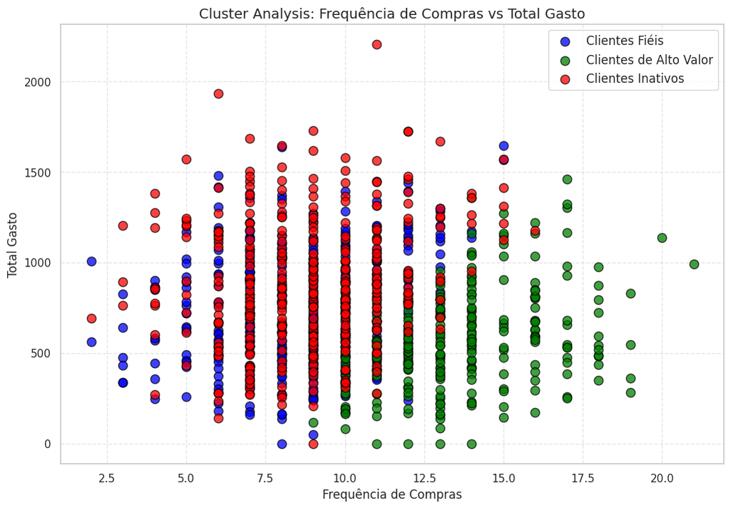

```
Campanhas com atributos sintéticos:
    nome_campanha  desconto  frete_gratis  brinde  investimento
0    black_friday         1             0       0         16361
1           natal         0             1       1          9721
2        dia_maes         0             1       1         12684
3        dia_pais         0             0       0         12198
4  volta_as_aulas         1             1       0         13136
Coluna 'conversion_rate' não encontrada em campanhas_df. Pule a visualização de conversão.
```

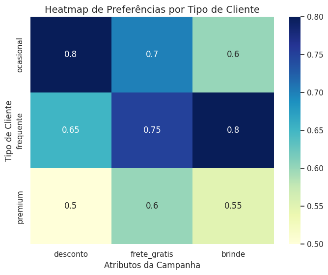

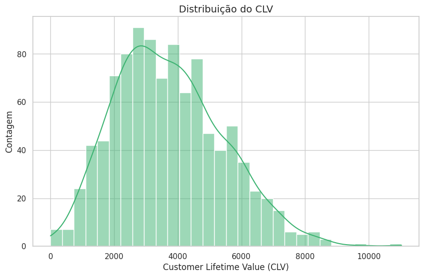

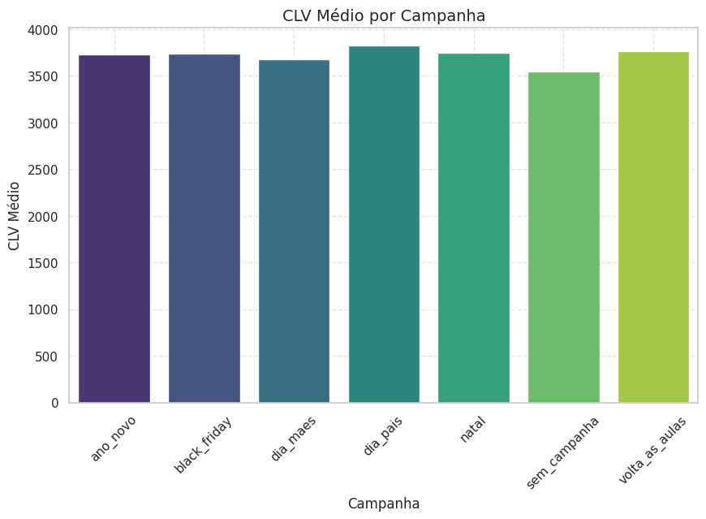

```
Número de clientes de alto valor: 199
Percentual de clientes de alto valor: 19.90%

Top 10 clientes por CLV:
     cliente_id  total_gasto  frequencia_compras      CLV
26           27       2206.0                  11  11030.0
12           13       1934.0                   6   9670.0
529         530       1728.0                   9   8640.0
863         864       1725.0                  12   8625.0
559         560       1725.0                  12   8625.0
619         620       1684.0                   7   8420.0
981         982       1670.0                  13   8350.0
966         967       1647.0                   8   8235.0
895         896       1644.0                  15   8220.0
998         999       1638.0                   8   8190.0
```

```python
# =========================
# Importar Bibliotecas
# =========================
import pandas as pd
import numpy as np
import statsmodels.api as sm
import matplotlib.pyplot as plt
import seaborn as sns

# Definir estilo geral dos plots
sns.set(style="whitegrid")

# =========================
# 1. Carregar os Dados
# =========================
# Carregar os datasets de clientes, campanhas e transações
clientes_df = pd.read_csv("clientes (1).csv")
campanhas_df = pd.read_csv("campanhas (1).csv")
transacoes_df = pd.read_csv("transacoes (1).csv")

# Visualizar as primeiras linhas para conferência
print("Clientes (head):")
print(clientes_df.head())
print("\nCampanhas (head):")
print(campanhas_df.head())
print("\nTransações (head):")
print(transacoes_df.head())

# =========================
# 2. Calcular o Total Gasto por Cliente
# =========================
# Agrupar os valores das transações (coluna 'valor_compra') por cliente
gasto_total_cliente = transacoes_df.groupby('cliente_id')['valor_compra'].sum().reset_index()
gasto_total_cliente.columns = ['cliente_id', 'computed_total_gasto']

# Unir ao dataset de clientes e preencher ausências com 0
clientes_df = clientes_df.merge(gasto_total_cliente, on='cliente_id', how='left')
clientes_df['total_gasto'] = clientes_df['computed_total_gasto'].fillna(0)
clientes_df.drop(columns=['computed_total_gasto'], inplace=True)

# =========================
# 3. Cluster Analysis - Segmentação dos Clientes
# =========================
# Selecionar as variáveis para clusterização: frequência de compras, total gasto e recência (dias desde a última compra)
cluster_features = clientes_df[['frequencia_compras', 'total_gasto', 'ultima_compra']]

# Padronizar as variáveis
from sklearn.preprocessing import StandardScaler
scaler = StandardScaler()
cluster_features_scaled = scaler.fit_transform(cluster_features)

# Aplicar o algoritmo K-Means para 3 clusters
from sklearn.cluster import KMeans
kmeans = KMeans(n_clusters=3, random_state=42)
clientes_df['cluster'] = kmeans.fit_predict(cluster_features_scaled)

# Definir rótulos e cores para os clusters (baseado em análise posterior)
cluster_labels = {0: 'Clientes Fiéis', 1: 'Clientes de Alto Valor', 2: 'Clientes Inativos'}
cluster_colors = {0: 'blue', 1: 'green', 2: 'red'}

# Visualização: Gráfico de Dispersão para Cluster Analysis
plt.figure(figsize=(12,8))
for cluster in sorted(clientes_df['cluster'].unique()):
    data = clientes_df[clientes_df['cluster'] == cluster]
    plt.scatter(data['frequencia_compras'], data['total_gasto'],
                color=cluster_colors[cluster],
                edgecolor='black',
                s=80, alpha=0.75,
                label=cluster_labels[cluster])
plt.xlabel("Frequência de Compras", fontsize=12)
plt.ylabel("Total Gasto", fontsize=12)
plt.title("Cluster Analysis: Frequência de Compras vs Total Gasto", fontsize=14)
plt.legend(fontsize=12)
plt.grid(True, linestyle='--', alpha=0.5)
plt.show()

# =========================
# 4. Campanha Preference Analysis - Processar Dados de Campanhas
# =========================
# Converter os nomes das campanhas para minúsculas
campanhas_df['nome_campanha'] = campanhas_df['nome_campanha'].str.lower()

# Renomear a coluna 'custo_campanha' para 'investimento'
campanhas_df.rename(columns={'custo_campanha': 'investimento'}, inplace=True)

# Função para atribuir atributos sintéticos (ex: desconto, frete grátis, brinde) com base no nome da campanha
def atribuir_atributos(nome):
    if 'black' in nome:
        return pd.Series({'desconto': 1, 'frete_gratis': 0, 'brinde': 0})
    elif 'natal' in nome:
        return pd.Series({'desconto': 0, 'frete_gratis': 1, 'brinde': 1})
    elif 'maes' in nome:
        return pd.Series({'desconto': 0, 'frete_gratis': 1, 'brinde': 1})
    elif 'pais' in nome:
        return pd.Series({'desconto': 0, 'frete_gratis': 0, 'brinde': 0})
    elif 'volta' in nome:
        return pd.Series({'desconto': 1, 'frete_gratis': 1, 'brinde': 0})
    else:
        return pd.Series({'desconto': 0, 'frete_gratis': 0, 'brinde': 0})

atributos = campanhas_df['nome_campanha'].apply(atribuir_atributos)
campanhas_df = pd.concat([campanhas_df, atributos], axis=1)

print("\nCampanhas com atributos sintéticos:")
print(campanhas_df[['nome_campanha', 'desconto', 'frete_gratis', 'brinde', 'investimento']].head())

# Se o dataset de campanhas contiver a taxa de conversão, podemos criar uma visualização
if 'conversion_rate' in campanhas_df.columns:
    plt.figure(figsize=(12,6))
    sns.barplot(x='nome_campanha', y='conversion_rate', data=campanhas_df, palette='muted')
    plt.xlabel("Campanha", fontsize=12)
    plt.ylabel("Taxa de Conversão", fontsize=12)
    plt.title("Taxa de Conversão por Campanha", fontsize=14)
    plt.xticks(rotation=45)
    plt.grid(True, linestyle='--', alpha=0.5)
    plt.show()
else:
    print("Coluna 'conversion_rate' não encontrada em campanhas_df. Pule a visualização de conversão.")

# Exemplo de Heatmap de Preferências por Tipo de Cliente (dados hipotéticos)
heatmap_data = pd.DataFrame({
    'desconto': [0.80, 0.65, 0.50],
    'frete_gratis': [0.70, 0.75, 0.60],
    'brinde': [0.60, 0.80, 0.55]
}, index=['ocasional', 'frequente', 'premium'])
plt.figure(figsize=(8,6))
sns.heatmap(heatmap_data, annot=True, cmap="YlGnBu")
plt.title("Heatmap de Preferências por Tipo de Cliente", fontsize=14)
plt.xlabel("Atributos da Campanha", fontsize=12)
plt.ylabel("Tipo de Cliente", fontsize=12)
plt.show()

# =========================
# 5. Regression Analysis - Impacto das Campanhas no Total Gasto
# =========================

# Antes de realizar a mesclagem, adicione a coluna 'campanha' ao dataframe clientes_df
# Simulando atribuição aleatória de campanhas aos clientes
import numpy as np
np.random.seed(42)  # Para reprodutibilidade
clientes_df['campanha'] = np.random.choice(campanhas_df['nome_campanha'], size=len(clientes_df))

# Unir os atributos da campanha com os dados dos clientes:
clientes_df = clientes_df.merge(
    campanhas_df[['nome_campanha', 'desconto', 'frete_gratis', 'brinde', 'investimento']],
    left_on='campanha', right_on='nome_campanha', how='left'
)

# =========================
# 6. CLV Analysis - Cálculo e Visualizações
# =========================
# Calcular o Customer Lifetime Value (CLV)
# Supondo que 'total_gasto' seja o valor anual, multiplicamos por um lifespan de 5 anos
lifespan = 5
clientes_df['CLV'] = clientes_df['total_gasto'] * lifespan

# Visualização: Histograma da Distribuição do CLV
plt.figure(figsize=(10,6))
sns.histplot(clientes_df['CLV'], bins=30, kde=True, color='mediumseagreen')
plt.xlabel("Customer Lifetime Value (CLV)", fontsize=12)
plt.ylabel("Contagem", fontsize=12)
plt.title("Distribuição do CLV", fontsize=14)
plt.show()

# Calcular e Visualizar o CLV Médio por Campanha
clv_por_campanha = clientes_df.groupby('campanha')['CLV'].mean().reset_index()
clv_por_campanha.columns = ['campanha', 'CLV_medio']
plt.figure(figsize=(10,6))
sns.barplot(x='campanha', y='CLV_medio', data=clv_por_campanha, palette='viridis')
plt.xlabel("Campanha", fontsize=12)
plt.ylabel("CLV Médio", fontsize=12)
plt.title("CLV Médio por Campanha", fontsize=14)
plt.xticks(rotation=45)
plt.grid(True, linestyle='--', alpha=0.5)
plt.show()

# =========================
# 7. Identificação dos Clientes de Alto Valor
# =========================
# Definir os clientes de alto valor como os que estão acima do 80º percentil de CLV
threshold = clientes_df['CLV'].quantile(0.8)
clientes_alto_valor = clientes_df[clientes_df['CLV'] > threshold]
print("\nNúmero de clientes de alto valor:", len(clientes_alto_valor))
print("Percentual de clientes de alto valor: {:.2f}%".format(100 * len(clientes_alto_valor) / len(clientes_df)))
top10_clv = clientes_df.sort_values(by='CLV', ascending=False)[['cliente_id', 'total_gasto', 'frequencia_compras', 'CLV']].head(10)
print("\nTop 10 clientes por CLV:")
print(top10_clv)
```

### **EXPLICAÇÃO DO CÓDIGO**

Nesta análise, partimos da integração dos datasets de clientes, transações e campanhas para calcular o total gasto por cliente. Com essa métrica, realizamos diversas análises:

Cluster Analysis: Usamos as variáveis frequência de compras, total gasto e recência para aplicar o algoritmo K-Means e segmentar a base em três grupos. O gráfico de dispersão, com cores distintas (azul, verde e vermelho), identifica visualmente os segmentos – correspondentes a Clientes Fiéis, Clientes de Alto Valor e Clientes Inativos.

Campanha Preference Analysis: Processamos os dados de campanhas, atribuindo atributos sintéticos como desconto, frete grátis e brinde com base nos nomes das campanhas. Um gráfico de barras (quando disponível) e um heatmap comparativo de preferências por tipo de cliente ajudam a entender os elementos que mais influenciam o comportamento.

Clientes de alto valor foram identificados como aqueles com CLV acima do 80º percentil, representando a elite que, embora seja uma parte menor da base, gera um impacto significativo na receita.

Principais pontos destacados:

Integração dos Dados: Permitiu transformar transações em métricas-chave, como total gasto e CLV.

Segmentação Visual: O gráfico de cluster destaca os diferentes perfis de clientes com clareza.

### **CAMPANHA**

Com base nos perfis identificados através da clusterização, modelagem de CLV e análise de comportamento de consumo, desenhamos uma campanha para atuar de forma segmentada e estratégica, com foco em maximizar o valor de cada cliente ao longo do tempo, aumentar a rentabilidade das campanhas e reduzir o custo de aquisição via reativação e fidelização.

Estratégia: Implementar um programa de bonificação progressiva, no qual o cliente é recompensado de acordo com o valor da compra. A cada patamar alcançado, um benefício é desbloqueado.

Justificativa: Este público já tem afinidade com a marca e responde bem às campanhas. Porém, o aumento do valor de compra depende de estímulo claro e escalável. Ao premiar gradualmente, a campanha preserva a frequência, mas eleva o tíquete — potencializando o CLV deste grupo.

2. **Clientes Inativos** 📊 Perfil: Possuem histórico de boas compras, mas estão afastados (recência alta). Apresentam potencial de retorno se bem estimulados.

Objetivo: Reengajar emocionalmente e reconduzir o cliente ao ciclo ativo de compras.

Estratégia: Disparar uma campanha de reativação personalizada, com abordagem empática, frete grátis e brinde exclusivo na recompra.

Objetivo: Reter esse grupo, reconhecer seu valor e aumentar ainda mais o vínculo com a marca, reduzindo o risco de churn silencioso.

Estratégia: Criar um programa VIP de fidelização e reconhecimento, com vantagens exclusivas: atendimento diferenciado, acesso antecipado a lançamentos, ofertas secretas e canais prioritários de suporte.

Justificativa: Este grupo representa menos de 20% da base, mas impacta de forma desproporcional no faturamento. São clientes que não precisam de descontos — precisam de valor percebido. Reconhecê-los é essencial para mantê-los próximos e convertê-los em defensores da marca.